# Part I - (Ford go bike)

# How does trip duration vary across user types (Customer or Subscriber), member_gender (Male, Female, Other), and different time periods of the day (e.g., morning, afternoon, evening, night)?

```python
def categorize_time_of_day(hour):
    if 5 <= hour < 12:
        return 'morning'
    elif 12 <= hour < 17:
        return 'afternoon'
    elif 17 <= hour < 21:
        return 'evening'
    else:
        return 'night'

df['start_time'] = pd.to_datetime(df['start_time'])
df['time_period'] = df['start_time'].dt.hour.apply(categorize_time_of_day)
```

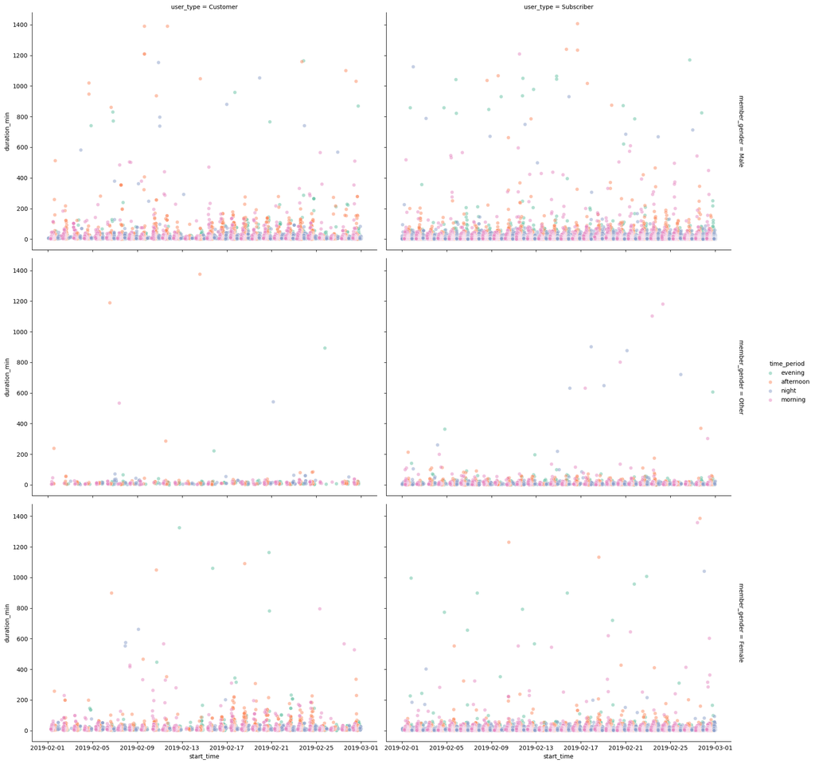

```python
# Convert duration_sec to duration_min
df['duration_min'] = df['duration_sec'] / 60

# Create a FacetGrid with scatter plots
g = sns.FacetGrid(df, col='user_type', row='member_gender', hue='time_period', palette='Set2', margin_titles=True, height=6, aspect=1.5)
g.map(sns.scatterplot, 'start_time', 'duration_min', alpha=0.5)
g.add_legend()

plt.show()
```

Let’s start with male gender. Male Comparing the two graphs of customer and subscriber, the subscribers have more duration per min in terms of biking. Other gender Comparing the two graphs of customer, and subscriber, subscribers clearly have more duration per min. Female Comparing the two graphs of customer, and subscriber, subscribers clearly have more duration per min.

# How does the age of the bike rider and the duration of the trip vary by user type, with the color representing whether the user shares bikes for all trips?

```python
import pandas as pd
current_year = pd.to_datetime('today').year
df['age'] = current_year - df['member_birth_year']
```

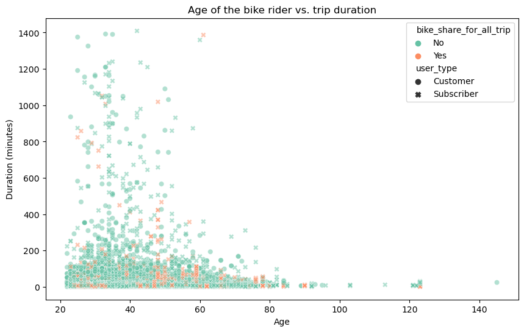

```python
df['duration_min'] = df['duration_sec'] / 60

# Create a scatter plot with a color palette
plt.figure(figsize=(10, 6))
sns.scatterplot(data=df, x='age', y='duration_min', hue='bike_share_for_all_trip', style='user_type', palette='Set2', alpha=0.5)
plt.title('Age of the bike rider vs. trip duration')
plt.xlabel('Age')
plt.ylabel('Duration (minutes)')

plt.show()
```

First in the age, the user-type both – subscribers and customers are between 20-60. When looking at the graph, between the age of 30-40, they take their trips duration the longest. When examining the shape of user type, quite interestingly, there are four circles, which represent customer. They have the longest trip duration between age 20-40. It seems they’re one time user of the bike such as tourist who use the bike entire day. Other than that, in terms of duration, it is quite balanced between customer and subscriber. Most trips take below 200 minutes for both customer and subscriber.

# Feature Engineering

This is my first try in trying to select and create variables that can lead to better insights. The goal is to find out which station are most popular, so management can decide whether to put more bikes or create more stations in the same location to increase revenue. Finding out the distanced travel per each user type can provide better insights into buying specific bicycle type that better suits the need.

# Can we calculate the total distance traveled using the start_station_latitude, start_station_longitude, end_station_latitude, and end_station_longitude to determine the most popular station and distances traveled?

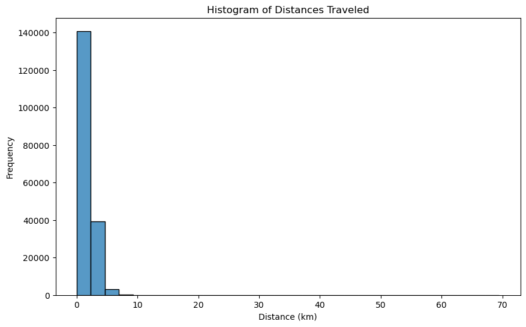

```python
def haversine_distance(lat1, lon1, lat2, lon2):
    R = 6371  # Earth radius in kilometers
    phi1 = np.radians(lat1)
    phi2 = np.radians(lat2)
    delta_phi = np.radians(lat2 - lat1)
    delta_lambda = np.radians(lon2 - lon1)
    a = np.sin(delta_phi / 2) ** 2 + np.cos(phi1) * np.cos(phi2) * np.sin(delta_lambda / 2) ** 2
    c = 2 * np.arctan2(np.sqrt(a), np.sqrt(1 - a))
    d = R * c
    return d

# Calculate the distance in kilometers and add it as a new column
df['distance_km'] = df.apply(lambda row: haversine_distance(row['start_station_latitude'], row['start_station_longitude'], row['end_station_latitude'], row['end_station_longitude']), axis=1)

# Plot the histogram
plt.figure(figsize=(10, 6))
sns.histplot(data=df, x='distance_km', bins=30)
plt.title('Histogram of Distances Traveled')
plt.xlabel('Distance (km)')
plt.ylabel('Frequency')
plt.show()
```

Most bikers only bike in 0-2 km. Very few bike in between 8-10km.

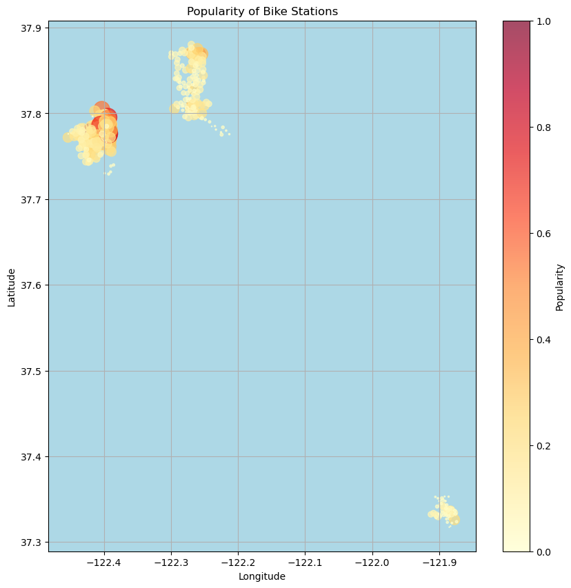

```python
start_station_counts = df['start_station_id'].value_counts().reset_index()
start_station_counts.columns = ['start_station_id', 'start_count']

end_station_counts = df['end_station_id'].value_counts().reset_index()
end_station_counts.columns = ['end_station_id', 'end_count']

stations = df[['start_station_id', 'start_station_latitude', 'start_station_longitude']].drop_duplicates()
stations = stations.merge(start_station_counts, on='start_station_id', how='left')
stations = stations.merge(end_station_counts, left_on='start_station_id', right_on='end_station_id', how='left')
stations['total_count'] = stations['start_count'].fillna(0) + stations['end_count'].fillna(0)

stations['normalized_count'] = (stations['total_count'] - stations['total_count'].min()) / (stations['total_count'].max() - stations['total_count'].min())

fig, ax = plt.subplots(figsize=(10, 10))
scatter = ax.scatter(stations['start_station_longitude'], stations['start_station_latitude'], s=stations['normalized_count'] * 500, c=stations['normalized_count'], cmap='YlOrRd', alpha=0.7)

cbar = plt.colorbar(scatter)
cbar.set_label('Popularity')

plt.xlabel('Longitude')
plt.ylabel('Latitude')
plt.title('Popularity of Bike Stations')

ax.set_facecolor('lightblue')
plt.grid(True)
plt.show()
```

It seems that the most popular stations ( in the red ) are located in the latitude of 37.8, and longitude of -122.4.

[figure not shown]

Upon researching, they're located in Pier zone, where people can bike with the view of water. Management should put up more bike station in this path.

## Conclusions

There are some suprising data when doing the analysis. There are tourists who use the bike entire day, thereby increasing trip per duration and distanced traveled. However most of the data are in check. Males tend to exercise more than females and other genders. Older people between 30-40 exercise more than younger ones 18-30.